# soulpageIT

## SoulPage IT Machine Learning Code test

##### CREATED BY: PIYUSH MAHAJAN

Problem Statement

You have a dataset related to characteristics of Beans like their Area, Perimeter, Roundness etc. Given that you have to build Machine learning model that can predict the class or category of bean

Dataset Description

The dataset folder contains the following files:

1. training dataset contained in train.csv file
2. Testing dataset contained in test.csv file

# TABLE OF CONTENTS

### 3.6 Logistic Regression Models

### 3.7 XGBoost Models

# 0. IMPORTS ⤒

```python
import pandas as pd
import numpy as np
import matplotlib.pyplot as plt
import seaborn as sns
import plotly.express as px
import plotly.graph_objects as go
import plotly.figure_factory as ff
import ppscore
from imblearn.over_sampling import SMOTE, KMeansSMOTE, SMOTEN, RandomOverSampler

from plotly.subplots import make_subplots
from sklearn.preprocessing import MinMaxScaler, StandardScaler, LabelEncoder, OneHotEncoder
from sklearn.metrics import classification_report, confusion_matrix, plot_confusion_matrix, roc_auc_score
from sklearn.model_selection import train_test_split, GridSearchCV, cross_val_score, KFold, StratifiedShuffleSplit
from sklearn.linear_model import LogisticRegression
from sklearn.ensemble import RandomForestClassifier, AdaBoostClassifier
from sklearn.pipeline import Pipeline, make_pipeline
from sklearn.feature_selection import SelectKBest, f_classif, chi2



from colorama import Fore
y_ = Fore.YELLOW
r_ = Fore.RED
g_ = Fore.GREEN
b_ = Fore.BLUE
m_ = Fore.MAGENTA
bl_ = Fore.BLACK


import warnings
warnings.filterwarnings('ignore')

plt.rcParams['figure.figsize'] = (10,8)
```

```python
class config:
    CSV_PATH = 'csv_files/'
    RANDOM_SEED = 15
```

```python
light_purpul = '#e0aaff'
```

```python
sns.dark_palette('#7b2cbf', n_colors=8)
```

# 1. DATASET ⤒

```python
os.listdir(config.CSV_PATH)
```

```
['test.csv', 'train.csv']
```

```python
train_df = pd.read_csv(config.CSV_PATH + 'train.csv')
test_df = pd.read_csv(config.CSV_PATH + 'test.csv')
```

```python
train_df.head()
```

|  | Area | Perimeter | MajorAxisLength | MinorAxisLength | AspectRation | Eccentricity | ConvexArea | EquivDiameter | Extent | Solidity | roundness | Compactness | ShapeFactor1 | ShapeFactor2 | ShapeFactor3 | ShapeFactor4 | Class |
| --- | --- | --- | --- | --- | --- | --- | --- | --- | --- | --- | --- | --- | --- | --- | --- | --- | --- |
| 0 | 54180 | 951.753 | 388.728347 | 178.948203 | 2.172295 | 0.887741 | 55014 | 262.648279 | 0.580210 | 0.984840 | 0.751624 | 0.675660 | 0.007175 | 0.000922 | 0.456517 | 0.991689 | HOROZ |
| 1 | 42023 | 746.715 | 272.962686 | 196.334047 | 1.390297 | 0.694730 | 42365 | 231.312225 | 0.795348 | 0.991927 | 0.947081 | 0.847413 | 0.006496 | 0.002066 | 0.718109 | 0.998386 | DERMASON |
| 2 | 38600 | 716.517 | 254.129288 | 193.991641 | 1.310001 | 0.645976 | 38940 | 221.691331 | 0.715265 | 0.991269 | 0.944809 | 0.872356 | 0.006584 | 0.002352 | 0.761006 | 0.996919 | SEKER |
| 3 | 62298 | 992.583 | 327.685094 | 242.658033 | 1.350399 | 0.672032 | 63353 | 281.638558 | 0.801157 | 0.983347 | 0.794603 | 0.859479 | 0.005260 | 0.001771 | 0.738705 | 0.997546 | BARBUNYA |
| 4 | 74456 | 1085.466 | 447.665972 | 212.382328 | 2.107831 | 0.880298 | 75096 | 307.896612 | 0.788821 | 0.991478 | 0.794104 | 0.687782 | 0.006012 | 0.000830 | 0.473044 | 0.997097 | HOROZ |

```python
train_df.shape
```

```
(9528, 17)
```

```python
test_df.shape
```

```
(4083, 17)
```

# 2. DATA EXPLORATION AND VISUALIZATION ⤒

## 2.1 Basic Exploration ⤒

- Let's Explore some Basic Things about dataset

```python
train_df.head()
```

|  | Area | Perimeter | MajorAxisLength | MinorAxisLength | AspectRation | Eccentricity | ConvexArea | EquivDiameter | Extent | Solidity | roundness | Compactness | ShapeFactor1 | ShapeFactor2 | ShapeFactor3 | ShapeFactor4 | Class |
| --- | --- | --- | --- | --- | --- | --- | --- | --- | --- | --- | --- | --- | --- | --- | --- | --- | --- |
| 0 | 54180 | 951.753 | 388.728347 | 178.948203 | 2.172295 | 0.887741 | 55014 | 262.648279 | 0.580210 | 0.984840 | 0.751624 | 0.675660 | 0.007175 | 0.000922 | 0.456517 | 0.991689 | HOROZ |
| 1 | 42023 | 746.715 | 272.962686 | 196.334047 | 1.390297 | 0.694730 | 42365 | 231.312225 | 0.795348 | 0.991927 | 0.947081 | 0.847413 | 0.006496 | 0.002066 | 0.718109 | 0.998386 | DERMASON |
| 2 | 38600 | 716.517 | 254.129288 | 193.991641 | 1.310001 | 0.645976 | 38940 | 221.691331 | 0.715265 | 0.991269 | 0.944809 | 0.872356 | 0.006584 | 0.002352 | 0.761006 | 0.996919 | SEKER |
| 3 | 62298 | 992.583 | 327.685094 | 242.658033 | 1.350399 | 0.672032 | 63353 | 281.638558 | 0.801157 | 0.983347 | 0.794603 | 0.859479 | 0.005260 | 0.001771 | 0.738705 | 0.997546 | BARBUNYA |
| 4 | 74456 | 1085.466 | 447.665972 | 212.382328 | 2.107831 | 0.880298 | 75096 | 307.896612 | 0.788821 | 0.991478 | 0.794104 | 0.687782 | 0.006012 | 0.000830 | 0.473044 | 0.997097 | HOROZ |

```python
train_df.tail()
```

|  | Area | Perimeter | MajorAxisLength | MinorAxisLength | AspectRation | Eccentricity | ConvexArea | EquivDiameter | Extent | Solidity | roundness | Compactness | ShapeFactor1 | ShapeFactor2 | ShapeFactor3 | ShapeFactor4 | Class |
| --- | --- | --- | --- | --- | --- | --- | --- | --- | --- | --- | --- | --- | --- | --- | --- | --- | --- |
| 9523 | 55381 | 914.969 | 363.142352 | 194.498350 | 1.867072 | 0.844473 | 55974 | 265.543366 | 0.765216 | 0.989406 | 0.831300 | 0.731238 | 0.006557 | 0.001156 | 0.534709 | 0.998339 | HOROZ |
| 9524 | 40987 | 749.125 | 272.565043 | 192.210719 | 1.418053 | 0.709016 | 41441 | 228.443142 | 0.708701 | 0.989045 | 0.917799 | 0.838123 | 0.006650 | 0.002024 | 0.702451 | 0.996113 | SIRA |
| 9525 | 32168 | 663.090 | 239.983107 | 171.160719 | 1.402092 | 0.700940 | 32570 | 202.379766 | 0.727536 | 0.987657 | 0.919367 | 0.843308 | 0.007460 | 0.002327 | 0.711169 | 0.997125 | DERMASON |
| 9526 | 53228 | 920.083 | 380.325304 | 178.969940 | 2.125079 | 0.882362 | 53905 | 260.330549 | 0.653939 | 0.987441 | 0.790125 | 0.684494 | 0.007145 | 0.000968 | 0.468533 | 0.995669 | HOROZ |
| 9527 | 50330 | 841.897 | 324.437513 | 198.042350 | 1.638223 | 0.792080 | 50882 | 253.144517 | 0.734316 | 0.989151 | 0.892316 | 0.780257 | 0.006446 | 0.001474 | 0.608800 | 0.997351 | SIRA |

```python
print(f'{y_} So We have total {b_}{train_df.shape[0]}{y_} rows and {b_}{train_df.shape[1]}{y_} Columns in Training dataset')
print(f'{y_} So We have total {b_}{test_df.shape[0]}{y_} rows and {b_}{test_df.shape[1]}{y_} Columns in Testing dataset')
```

```
 So We have total 9528 rows and 17 Columns in Training dataset
 So We have total 4083 rows and 17 Columns in Testing dataset
```

```python
train_df.describe().T.style.bar(axis = 1, subset=['mean', 'min', '25%', '50%', '75%', 'max'], color =  '#3bb4f7')
```

|  | count | mean | std | min | 25% | 50% | 75% | max |
| --- | --- | --- | --- | --- | --- | --- | --- | --- |
| Area | 9528.000000 | 53255.524664 | 29609.257209 | 20464.000000 | 36453.750000 | 44754.500000 | 61444.750000 | 254616.000000 |
| Perimeter | 9528.000000 | 856.676016 | 215.627112 | 524.736000 | 704.791500 | 796.506000 | 977.826000 | 1985.370000 |
| MajorAxisLength | 9528.000000 | 320.572294 | 86.225872 | 183.965251 | 253.499188 | 297.211791 | 376.865074 | 738.860153 |
| MinorAxisLength | 9528.000000 | 202.687297 | 45.235551 | 122.512653 | 176.261896 | 192.789907 | 217.042845 | 460.198497 |
| AspectRation | 9528.000000 | 1.582178 | 0.247600 | 1.036423 | 1.430546 | 1.549658 | 1.706178 | 2.430306 |
| Eccentricity | 9528.000000 | 0.750259 | 0.092649 | 0.262774 | 0.715089 | 0.763926 | 0.810235 | 0.911423 |
| ConvexArea | 9528.000000 | 53975.731423 | 30067.830953 | 20772.000000 | 36844.750000 | 45290.500000 | 62391.000000 | 263261.000000 |
| EquivDiameter | 9528.000000 | 253.496647 | 59.555540 | 161.417391 | 215.439913 | 238.711540 | 279.703209 | 569.374358 |
| Extent | 9528.000000 | 0.750049 | 0.049182 | 0.555315 | 0.719528 | 0.760305 | 0.787088 | 0.866195 |
| Solidity | 9528.000000 | 0.987197 | 0.004600 | 0.919246 | 0.985704 | 0.988315 | 0.990065 | 0.994213 |
| roundness | 9528.000000 | 0.873459 | 0.059669 | 0.556766 | 0.832908 | 0.883106 | 0.917196 | 0.990685 |
| Compactness | 9528.000000 | 0.800216 | 0.062001 | 0.640577 | 0.762764 | 0.801603 | 0.834551 | 0.981611 |
| ShapeFactor1 | 9528.000000 | 0.006551 | 0.001129 | 0.002778 | 0.005899 | 0.006632 | 0.007256 | 0.010451 |
| ShapeFactor2 | 9528.000000 | 0.001716 | 0.000597 | 0.000564 | 0.001154 | 0.001695 | 0.002172 | 0.003665 |
| ShapeFactor3 | 9528.000000 | 0.644190 | 0.099502 | 0.410339 | 0.581809 | 0.642568 | 0.696476 | 0.963560 |
| ShapeFactor4 | 9528.000000 | 0.995117 | 0.004259 | 0.947687 | 0.993739 | 0.996396 | 0.997909 | 0.999733 |

```python
train_df.info()
```

```
<class 'pandas.core.frame.DataFrame'>
RangeIndex: 9528 entries, 0 to 9527
Data columns (total 17 columns):
 #   Column           Non-Null Count  Dtype
---  ------           --------------  -----
 0   Area             9528 non-null   int64
 1   Perimeter        9528 non-null   float64
 2   MajorAxisLength  9528 non-null   float64
 3   MinorAxisLength  9528 non-null   float64
 4   AspectRation     9528 non-null   float64
 5   Eccentricity     9528 non-null   float64
 6   ConvexArea       9528 non-null   int64
 7   EquivDiameter    9528 non-null   float64
 8   Extent           9528 non-null   float64
 9   Solidity         9528 non-null   float64
 10  roundness        9528 non-null   float64
 11  Compactness      9528 non-null   float64
 12  ShapeFactor1     9528 non-null   float64
 13  ShapeFactor2     9528 non-null   float64
 14  ShapeFactor3     9528 non-null   float64
 15  ShapeFactor4     9528 non-null   float64
 16  Class            9528 non-null   object
dtypes: float64(14), int64(2), object(1)
memory usage: 1.2+ MB
```

```python
train_df.isnull().sum()
```

```
Area               0
Perimeter          0
MajorAxisLength    0
MinorAxisLength    0
AspectRation       0
Eccentricity       0
ConvexArea         0
EquivDiameter      0
Extent             0
Solidity           0
roundness          0
Compactness        0
ShapeFactor1       0
ShapeFactor2       0
ShapeFactor3       0
ShapeFactor4       0
Class              0
dtype: int64
```

## 2.2 Duplicate Values ⤒

Let's Check is there any duplicate values exist or not

**🛑 NOTE:**  
- How to Handle duplicates is completely in the hands of Data Scientist or Machine learning engineer.  
- You can drop them or Just keep them, Both have their Advantage and Dis-advantages  
- If There are Duplicates in the training set, it results in increasing the sample weight of those cases. In That case, Removal of true duplicates will be a good thing.  
- But There are scenarios where duplicated data has meaning and in that case we keeps the duplicates In Given Dataset, I am going to keep the duplicates. Because The dataset is about characteristics of Beans and there are chances that two beans may have exact same characteristics, but still they are two different Beans. So i am going to keep them, Still i will decide this during countplots.

```python
train_df[train_df.duplicated(keep = False)].shape
```

```
(74, 17)
```

```python
duplicate_counts = pd.DataFrame(train_df.value_counts())
```

```python
duplicate_counts.head(40)
```

| Area | Perimeter | MajorAxisLength | MinorAxisLength | AspectRation | Eccentricity | ConvexArea | EquivDiameter | Extent | Solidity | roundness | Compactness | ShapeFactor1 | ShapeFactor2 | ShapeFactor3 | ShapeFactor4 | Class | 0 |
| --- | --- | --- | --- | --- | --- | --- | --- | --- | --- | --- | --- | --- | --- | --- | --- | --- | --- |
| 54860 | 911.589 | 369.730500 | 189.842876 | 1.947561 | 0.858112 | 55468 | 264.291357 | 0.691838 | 0.989039 | 0.829598 | 0.714822 | 0.006740 | 0.001085 | 0.510970 | 0.995145 | HOROZ | 2 |
| 59605 | 1001.665 | 399.345710 | 196.111065 | 2.036324 | 0.871114 | 62307 | 275.484016 | 0.778326 | 0.956634 | 0.746531 | 0.689838 | 0.006700 | 0.000936 | 0.475877 | 0.969040 | HOROZ | 2 |
| 42450 | 828.116 | 347.951525 | 156.469366 | 2.223768 | 0.893186 | 42820 | 232.484448 | 0.609388 | 0.991359 | 0.777867 | 0.668152 | 0.008197 | 0.001008 | 0.446427 | 0.992750 | HOROZ | 2 |
| 60942 | 1020.605 | 413.970269 | 187.850317 | 2.203724 | 0.891115 | 61764 | 278.556573 | 0.678400 | 0.986691 | 0.735210 | 0.672890 | 0.006793 | 0.000859 | 0.452781 | 0.997805 | HOROZ | 2 |
| 33954 | 716.750 | 277.368480 | 156.356326 | 1.773951 | 0.825970 | 34420 | 207.922042 | 0.799482 | 0.986461 | 0.830549 | 0.749624 | 0.008169 | 0.001591 | 0.561936 | 0.996847 | HOROZ | 2 |
| 54187 | 919.972 | 372.954622 | 186.450123 | 2.000292 | 0.866067 | 54828 | 262.665246 | 0.759241 | 0.988309 | 0.804555 | 0.704282 | 0.006883 | 0.001045 | 0.496013 | 0.992171 | HOROZ | 2 |
| 54160 | 929.492 | 349.459450 | 202.934731 | 1.722029 | 0.814110 | 55623 | 262.599798 | 0.749505 | 0.973698 | 0.787766 | 0.751446 | 0.006452 | 0.001269 | 0.564671 | 0.972379 | HOROZ | 2 |
| 46863 | 867.433 | 347.442755 | 172.128791 | 2.018505 | 0.868656 | 47538 | 244.269983 | 0.700703 | 0.985801 | 0.782651 | 0.703051 | 0.007414 | 0.001117 | 0.494281 | 0.997708 | HOROZ | 2 |
| 62764 | 1003.767 | 409.207082 | 198.330199 | 2.063262 | 0.874697 | 64158 | 282.689948 | 0.703995 | 0.978272 | 0.782807 | 0.690824 | 0.006520 | 0.000916 | 0.477237 | 0.984666 | HOROZ | 2 |
| 49730 | 879.912 | 365.825690 | 173.569194 | 2.107665 | 0.880278 | 50263 | 251.631084 | 0.789365 | 0.989396 | 0.807142 | 0.687844 | 0.007356 | 0.001016 | 0.473130 | 0.997199 | HOROZ | 2 |
| 41978 | 821.864 | 337.171464 | 160.036067 | 2.106847 | 0.880178 | 42593 | 231.188342 | 0.684885 | 0.985561 | 0.780965 | 0.685670 | 0.008032 | 0.001095 | 0.470143 | 0.990520 | HOROZ | 2 |
| 51142 | 898.882 | 357.519999 | 182.737640 | 1.956466 | 0.859506 | 51746 | 255.178402 | 0.783629 | 0.988328 | 0.795394 | 0.713746 | 0.006991 | 0.001119 | 0.509433 | 0.996689 | HOROZ | 2 |
| 53978 | 924.848 | 366.147740 | 189.438667 | 1.932804 | 0.855754 | 54949 | 262.158204 | 0.627272 | 0.982329 | 0.793023 | 0.715990 | 0.006783 | 0.001100 | 0.512642 | 0.990836 | HOROZ | 2 |
| 46696 | 862.883 | 354.981027 | 168.054453 | 2.112298 | 0.880838 | 47259 | 243.834357 | 0.778228 | 0.988087 | 0.788108 | 0.686894 | 0.007602 | 0.001044 | 0.471823 | 0.996632 | HOROZ | 2 |
| 40804 | 790.802 | 323.475648 | 163.287717 | 1.981016 | 0.863241 | 41636 | 227.932592 | 0.787570 | 0.980017 | 0.819931 | 0.704636 | 0.007928 | 0.001206 | 0.496512 | 0.983598 | HOROZ | 2 |
| 56413 | 929.481 | 377.880838 | 191.039673 | 1.978023 | 0.862794 | 57007 | 268.006087 | 0.661240 | 0.989580 | 0.820556 | 0.709234 | 0.006698 | 0.001045 | 0.503013 | 0.994972 | HOROZ | 2 |
| 61076 | 982.932 | 417.474629 | 187.277110 | 2.229181 | 0.893735 | 61597 | 278.862652 | 0.824071 | 0.991542 | 0.794390 | 0.667975 | 0.006835 | 0.000839 | 0.446191 | 0.994640 | HOROZ | 2 |
| 53607 | 929.682 | 385.118850 | 177.724071 | 2.166948 | 0.887151 | 54178 | 261.255722 | 0.717592 | 0.989461 | 0.779404 | 0.678377 | 0.007184 | 0.000939 | 0.460195 | 0.997219 | HOROZ | 2 |
| 56539 | 943.147 | 370.374563 | 196.675975 | 1.883171 | 0.847360 | 57599 | 268.305219 | 0.695728 | 0.981597 | 0.798729 | 0.724416 | 0.006551 | 0.001113 | 0.524778 | 0.988248 | HOROZ | 2 |
| 63882 | 1004.206 | 411.263403 | 198.765453 | 2.069089 | 0.875452 | 64663 | 285.196579 | 0.754705 | 0.987922 | 0.796054 | 0.693465 | 0.006438 | 0.000918 | 0.480893 | 0.995010 | HOROZ | 2 |
| 51515 | 896.279 | 375.980183 | 174.907355 | 2.149596 | 0.885204 | 52000 | 256.107273 | 0.804294 | 0.990673 | 0.805855 | 0.681172 | 0.007298 | 0.000969 | 0.463996 | 0.997403 | HOROZ | 2 |
| 63948 | 996.497 | 412.297178 | 198.877557 | 2.073121 | 0.875971 | 64641 | 285.343867 | 0.777909 | 0.989279 | 0.809254 | 0.692083 | 0.006447 | 0.000912 | 0.478979 | 0.992981 | HOROZ | 2 |
| 56761 | 959.439 | 398.376766 | 182.085518 | 2.187855 | 0.889431 | 57299 | 268.831452 | 0.591408 | 0.990611 | 0.774863 | 0.674817 | 0.007018 | 0.000898 | 0.455378 | 0.996301 | HOROZ | 2 |
| 56889 | 951.582 | 384.236934 | 190.177318 | 2.020414 | 0.868923 | 57644 | 269.134399 | 0.613504 | 0.986902 | 0.789488 | 0.700439 | 0.006754 | 0.001003 | 0.490614 | 0.991244 | HOROZ | 2 |
| 57029 | 953.664 | 388.137971 | 187.927020 | 2.065365 | 0.874971 | 57971 | 269.465356 | 0.784065 | 0.983750 | 0.787979 | 0.694251 | 0.006806 | 0.000975 | 0.481985 | 0.995475 | HOROZ | 2 |
| 58891 | 966.204 | 397.793919 | 189.528762 | 2.098858 | 0.879202 | 59522 | 273.829053 | 0.601420 | 0.989399 | 0.792722 | 0.688369 | 0.006755 | 0.000936 | 0.473852 | 0.994548 | HOROZ | 2 |
| 51894 | 901.802 | 367.354766 | 182.162461 | 2.016633 | 0.868393 | 52605 | 257.047647 | 0.653059 | 0.986484 | 0.801871 | 0.699726 | 0.007079 | 0.001047 | 0.489616 | 0.987376 | HOROZ | 2 |
| 51903 | 908.476 | 366.544714 | 181.189268 | 2.022994 | 0.869282 | 52611 | 257.069936 | 0.708825 | 0.986543 | 0.790270 | 0.701333 | 0.007062 | 0.001054 | 0.491868 | 0.995046 | HOROZ | 2 |
| 43746 | 836.693 | 339.352567 | 165.411442 | 2.051566 | 0.873161 | 44442 | 236.006646 | 0.713778 | 0.984339 | 0.785264 | 0.695462 | 0.007757 | 0.001119 | 0.483667 | 0.992274 | HOROZ | 2 |
| 52313 | 896.732 | 352.482089 | 189.300951 | 1.862020 | 0.843550 | 53085 | 258.083282 | 0.785198 | 0.985457 | 0.817512 | 0.732188 | 0.006738 | 0.001195 | 0.536100 | 0.998228 | HOROZ | 2 |
| 61911 | 985.026 | 408.790035 | 194.117337 | 2.105891 | 0.880062 | 62612 | 280.762415 | 0.787712 | 0.988804 | 0.801830 | 0.686813 | 0.006603 | 0.000906 | 0.471712 | 0.993375 | HOROZ | 2 |
| 53679 | 949.603 | 354.397129 | 195.980161 | 1.808332 | 0.833184 | 54804 | 261.431110 | 0.715386 | 0.979472 | 0.748049 | 0.737678 | 0.006602 | 0.001206 | 0.544169 | 0.984039 | HOROZ | 2 |
| 54954 | 917.472 | 347.661334 | 204.850538 | 1.697146 | 0.807969 | 56139 | 264.517685 | 0.832510 | 0.978892 | 0.820396 | 0.760849 | 0.006326 | 0.001308 | 0.578891 | 0.982462 | HOROZ | 2 |
| 38427 | 756.323 | 306.533886 | 160.591784 | 1.908777 | 0.851782 | 38773 | 221.193978 | 0.796976 | 0.991076 | 0.844174 | 0.721597 | 0.007977 | 0.001334 | 0.520702 | 0.993905 | HOROZ | 2 |
| 47134 | 870.142 | 360.775000 | 167.488454 | 2.154029 | 0.885706 | 47862 | 244.975249 | 0.623688 | 0.984790 | 0.782283 | 0.679025 | 0.007654 | 0.001004 | 0.461075 | 0.993169 | HOROZ | 2 |
| 54689 | 911.217 | 372.146327 | 187.816831 | 1.981432 | 0.863303 | 55206 | 263.879134 | 0.726861 | 0.990635 | 0.827687 | 0.709074 | 0.006805 | 0.001061 | 0.502785 | 0.996235 | HOROZ | 2 |
| 44614 | 850.425 | 351.268986 | 162.308089 | 2.164211 | 0.886848 | 45243 | 238.336546 | 0.633956 | 0.986097 | 0.775191 | 0.678502 | 0.007874 | 0.001029 | 0.460364 | 0.996326 | HOROZ | 2 |
| 53174 | 876.633 | 330.751298 | 205.727324 | 1.607717 | 0.783017 | 53778 | 260.198462 | 0.714589 | 0.988769 | 0.869508 | 0.786689 | 0.006220 | 0.001470 | 0.618880 | 0.994984 | HOROZ | 1 |
| 53179 | 911.324 | 371.476926 | 183.453443 | 2.024911 | 0.869548 | 53744 | 260.210695 | 0.670698 | 0.989487 | 0.804645 | 0.700476 | 0.006985 | 0.001037 | 0.490667 | 0.993557 | HOROZ | 1 |
| 53181 | 961.414 | 390.322181 | 175.636765 | 2.222326 | 0.893039 | 54343 | 260.215588 | 0.653361 | 0.978617 | 0.723012 | 0.666669 | 0.007340 | 0.000894 | 0.444447 | 0.987707 | HOROZ | 1 |

**✅ OBSERVATION:**  
- DataFrame Given above shows will observation occurs how many time  
- For Example First observation has occured two times  
- There is one Interesting Thing, all duplicates belongs to same target category. So It might result in biased model because of these duplicates  
- I will make final decision about Duplicate values in following section of countplot

## 2.3 Count Plots and Histogram ⤒

```python
px.histogram(x = train_df.Class, color=train_df.Class)
```

[output not shown]

**✅ OBSERVATION:**  
- Ohhh 😲, Dataset is Imbalance. So now i am going to keep duplicate values and Also going to balance dataset using different methods  
- Let's Plots some more histgram

```python
col_name=train_df.columns
fig = make_subplots(rows = 8, cols = 2, subplot_titles= col_name[:-1], vertical_spacing= 0.03)
col_no = 0
for i in range(1,9):
    for col in range(1,3):
        trace = go.Histogram(x = train_df[col_name[col_no]], name = col_name[col_no],)
        fig.append_trace(trace, i, col)
        col_no +=1

fig.update_layout(height = 2300,
    # margin=dict(
    #     # l=10,
    #     # r=10,
    #     b=1,
    #     t=20,
    #     pad=1
    # )
)
```

[output not shown]

**✅ OBSERVATION:**  
- Many Features have same distribution like **'Area', 'Perimeter', 'MajorAxisLength', 'MinorAxisLength', 'ConvexArea', 'EquivDiameter'**  
- Features like **'AspectRation', 'Compactness', 'ShapeFactor2', 'ShapeFactor3'** Have same type of Distribution  
To get more information, Let's Color them according to class

```python
train_df.columns
```

```
Index(['Area', 'Perimeter', 'MajorAxisLength', 'MinorAxisLength',
       'AspectRation', 'Eccentricity', 'ConvexArea', 'EquivDiameter', 'Extent',
       'Solidity', 'roundness', 'Compactness', 'ShapeFactor1', 'ShapeFactor2',
       'ShapeFactor3', 'ShapeFactor4', 'Class'],
      dtype='object')
```

```python
px.histogram(x = train_df.Perimeter, color= train_df.Class, title='Perimeter Histogram plot')
```

[output not shown]

```python
px.histogram(x = train_df.AspectRation, color= train_df.Class)
```

```python
px.histogram(x = train_df.Eccentricity, color= train_df.Class)
```

```python
px.histogram(x = train_df.ShapeFactor4 , color= train_df.Class)
```

**✅ OBSERVATION:**  
- From Perimeter plot, we can easly predict BOMBAY Class Bean and I think same goes for columns having same distribution as Perimeter plot

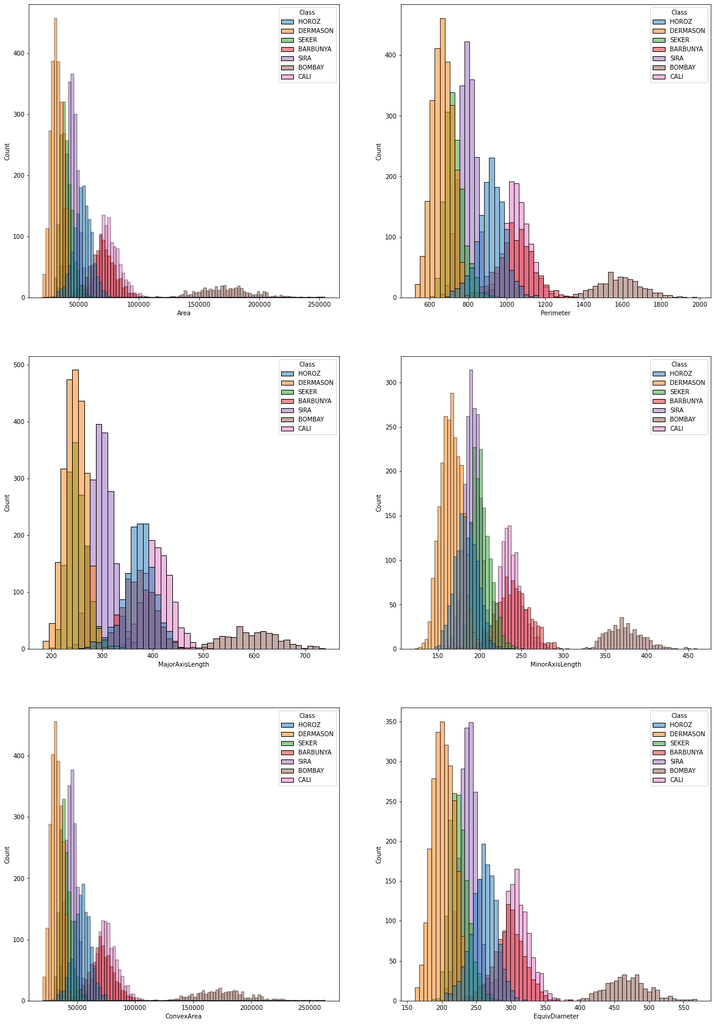

```python
fig, axs = plt.subplots(nrows = 3, ncols = 2, figsize = (20,30))
col_names = ['Area', 'Perimeter', 'MajorAxisLength', 'MinorAxisLength', 'ConvexArea', 'EquivDiameter']
col_no = 0
for row in range(3):
    for col in range(2):
        sns.histplot(ax = axs[row, col],x = train_df[col_names[col_no]], hue= train_df.Class)
        col_no+=1

fig.show()
```

**✅ OBSERVATION:**  
- So, Yes it is true, We can Separate BOMBAY bean class easily from other beans.  
- Interesting Fact: BOMBAY beans are way larger and bigger than other beans Lets Plot some Scatter plot to understand better

## 2.4 Pie chart ⤒

```python
def Pie_plots(data_frame, feature_name):
    label = data_frame[feature_name].value_counts().index
    values = data_frame[feature_name].value_counts().values
    fig = go.Figure(data=[go.Pie(labels=label, values = values,
         hole=0.3, pull = [0.025]*len(label),
         )])
    fig.show()
```

```python
Pie_plots(train_df, 'Class')
```

## 2.5 Scatter plots and Pair plot ⤒

> - **First i am going to plot pair plot of all features and them i will work on separate scatterplot**
> - And it will take a long time

```python
# sns.pairplot(data = train_df,)
```

[figure not shown]

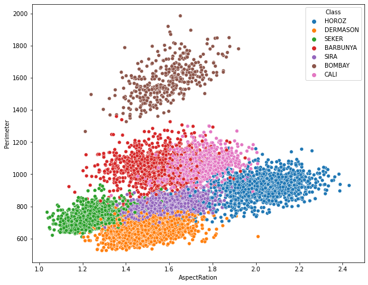

```python
sns.scatterplot(x = train_df.AspectRation, y = train_df.Perimeter, hue = train_df.Class)
```

```python
px.scatter(x = train_df.Area, y = train_df.Perimeter, color = train_df.Class )
```

**✅ OBSERVATION:**  
- Again There is same pattern as we expected in case of BOMBAY beans.  
- The other beans are also clustered around their repective centers. Now Let's go for boxplot to visualize the outliers

## 2.6 Box and Voilin plot ⤒

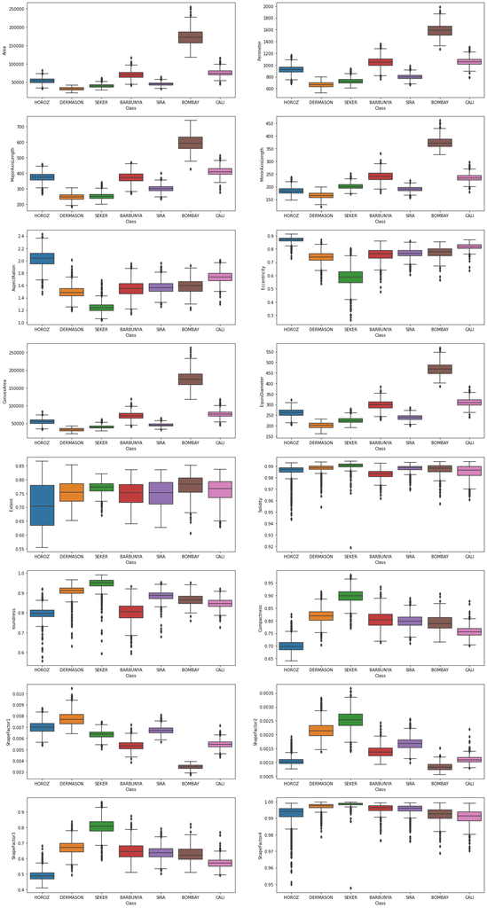

```python
fig, axs = plt.subplots(8,2, figsize = (20,40))
i = 0
for row in range(8):
    for col in range(2):
        sns.boxplot(ax= axs[row, col],y = train_df[train_df.columns[i]], x = train_df.Class)
        i+=1
```

**✅ OBSERVATION:**  
- There is one observation which is really odd, you can see in last boxplot in SEKER class.  
- I am going to drop that observation

```python
train_df[(train_df.ShapeFactor4 < 0.96) & (train_df.Class == 'SEKER')]
```

|  | Area | Perimeter | MajorAxisLength | MinorAxisLength | AspectRation | Eccentricity | ConvexArea | EquivDiameter | Extent | Solidity | roundness | Compactness | ShapeFactor1 | ShapeFactor2 | ShapeFactor3 | ShapeFactor4 | Class |
| --- | --- | --- | --- | --- | --- | --- | --- | --- | --- | --- | --- | --- | --- | --- | --- | --- | --- |
| 8817 | 34924 | 816.638 | 258.319787 | 181.639926 | 1.422153 | 0.711032 | 37992 | 210.871093 | 0.712095 | 0.919246 | 0.658074 | 0.816318 | 0.007397 | 0.002026 | 0.666375 | 0.947687 | SEKER |

```python
train_df.drop(labels= 8817, axis = 0, inplace = True)
train_df.reset_index(drop = True, inplace= True)
```

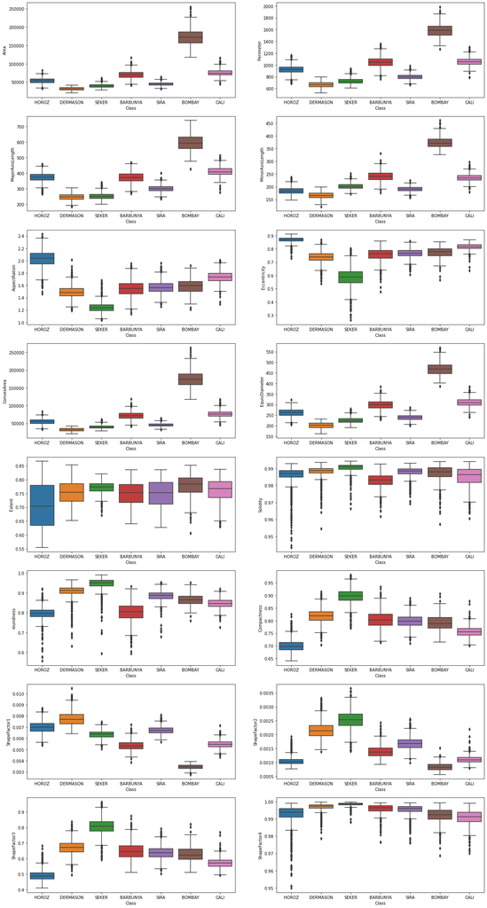

```python
fig, axs = plt.subplots(8,2, figsize = (20,40))
i = 0
for row in range(8):
    for col in range(2):
        sns.boxplot(ax= axs[row, col],y = train_df[train_df.columns[i]], x = train_df.Class)
        i+=1
```

**✅ OBSERVATION:**  
- That point was truly Outlier because you can see changes in ShapeFactor4 and Solidity Now Let's find out correlation between features

## 2.7 Correlation plot ⤒

- Here i am going to use Pearson Correlation and Predictive Power Score

```python
fig = px.imshow(train_df.corr(), text_auto= True, title= 'Pearson Correlation')
fig.update_layout(width = 600, height = 600)
fig.show()
```

```python
heat_map=ppscore.matrix(train_df)[['x', 'y', 'ppscore']].pivot(columns='x', index='y', values='ppscore')
fig = px.imshow(heat_map, text_auto= True, title= 'Predictive Power Score')
fig.update_layout(width = 650, height = 650)
fig.show()
```

**🛑 NOTE:**  
- The Labels in Predictive power score are sorted in alphabetical order Now we are going to balance the dataset, but first we need to encode the categorical variable

## 2.8 Encoding ⤒

```python
label_encoder = LabelEncoder()
label_encoder=label_encoder.fit(train_df.Class)
```

```python
Y = label_encoder.transform(train_df.Class)
```

```python
Y_TEST = label_encoder.transform(test_df.Class)
```

```python
Y_TEST
```

```
array([5, 5, 5, ..., 3, 3, 3])
```

```python
label_encoder.classes_
```

```
array(['BARBUNYA', 'BOMBAY', 'CALI', 'DERMASON', 'HOROZ', 'SEKER', 'SIRA'],
      dtype=object)
```

## 2.9 Balancing dataset ⤒

```python
smote = SMOTE(random_state= config.RANDOM_SEED)
```

```python
X_SMOTE, Y_SMOTE = smote.fit_resample(train_df.iloc[:,:-1], Y)
```

```python
Y_SMOTE
```

```
array([4, 3, 5, ..., 6, 6, 6])
```

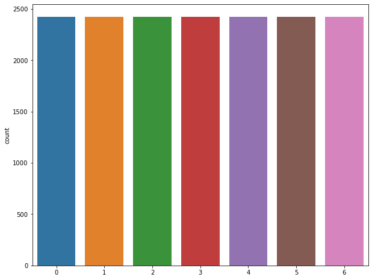

```python
sns.countplot(x =Y_SMOTE)
```

```python
X_SMOTE.shape, Y_SMOTE.shape
```

```
((16989, 16), (16989,))
```

```python
X_SMOTE.shape[0]-train_df.shape[0]
```

```
7462
```

```python
X_TEST = test_df.iloc[:,:-1]
```

```python
X_TEST.shape
```

```
(4083, 16)
```

**🛑 NOTE:**  
- Now the dataset is balanced and it have total 16989 row in total, that means total 7462 rows has been added Now dataset is balanced and Now we can move toward model building

# 3. MODEL BUILDING ⤒

**🚀 APPROACH**  
- For model building, I am going to use two types of dataset 1. Whole dataset and 2. Selecting K-best Features  
- The dataset is going to be splitted into two parts one for training and other for validation purpose and we already have separate dataset for testing.  
- For starting I am going to use logistic Regression model, because of its simplicity and easy to use. After that if logistic model failed to give good accuracy and other metrics, Then I will try different models  
- I am going to use Feature Transformation, because all feature have different range and units, so i am going to use MinMax Scaler.

## 3.1 Model Imports ⤒

```python
# pip install pycaret
from xgboost import XGBClassifier
```

## 3.2 Feature Selection ⤒

Selecting Best K features using SelectKBest

```python
select_k_best = SelectKBest(f_classif)
select_k_best.fit(X_SMOTE, Y_SMOTE)
```

```
SelectKBest()
```

```python
X_TRAIN_BEST = select_k_best.transform(X_SMOTE)
X_TEST_BEST = select_k_best.transform(X_TEST)
```

```python
X_TEST_BEST.shape
```

```
(4083, 10)
```

So there are 10 Best Features

## 3.3 Data Splitting ⤒

**🚀 Approach**  
- Here I am going to split those two datasets  
1. Best K feature dataset into 2 part for training and validation with 30% size.  
2. Whole dataset into 2 part for training and validation with 30% size.

### Best K feature Dataset

```python
x_train, x_val, y_train, y_val = train_test_split(X_TRAIN_BEST, Y_SMOTE,
        random_state= config.RANDOM_SEED, test_size= 0.3, )
```

```python
x_test, y_test = X_TEST_BEST, Y_TEST
```

```python
x_train.shape, y_train.shape, x_val.shape, y_val.shape, x_test.shape
```

```
((11892, 10), (11892,), (5097, 10), (5097,), (4083, 10))
```

```python
x_test.shape, y_test.shape
```

```
((4083, 10), (4083,))
```

### All Features

```python
x_train_whole, x_val_whole, y_train_whole, y_val_whole = train_test_split(X_SMOTE, Y_SMOTE,
        random_state= config.RANDOM_SEED, test_size= 0.3)
```

```python
x_test_whole, y_test_whole = X_TEST, Y_TEST
```

```python
x_train_whole.shape, y_train_whole.shape
```

```
((11892, 16), (11892,))
```

```python
x_test_whole.shape
```

```
(4083, 16)
```

## 3.4 Feature Scaling ⤒

Scalling Both datasets using MinMaxScaler

### Scaling K-Best data

```python
minmax = MinMaxScaler()
minmax =minmax.fit(x_train)
```

```python
x_train = minmax.transform(x_train)
x_val = minmax.transform(x_val)
x_test = minmax.transform(x_test)
```

### Scaling whole data

```python
minmax_whole = MinMaxScaler()
minmax_whole = minmax_whole.fit(x_train_whole)
```

```python
x_train_whole = minmax_whole.transform(x_train_whole)
x_val_whole = minmax_whole.transform(x_val_whole)
x_test_whole = minmax_whole.transform(x_test_whole)
```

## 3.6 Logistic Regression ⤒

### Model 1

#### Model trained on K-best data

```python
logistic = LogisticRegression(max_iter= 500)
logistic.fit(x_train, y_train)
```

```
LogisticRegression(max_iter=500)
```

```python
logistic.score(x_train, y_train)
```

```
0.9091826437941474
```

```python
logistic.score(x_val, y_val)
```

```
0.9207376888365705
```

```python
logistic.score(x_test, y_test)
```

```
0.8888072495713936
```

Wow, This is really good accuracy in first trial

```python
label_encoder.classes_
```

```
array(['BARBUNYA', 'BOMBAY', 'CALI', 'DERMASON', 'HOROZ', 'SEKER', 'SIRA'],
      dtype=object)
```

```
<sklearn.metrics._plot.confusion_matrix.ConfusionMatrixDisplay at 0x18556ea03d0>
```

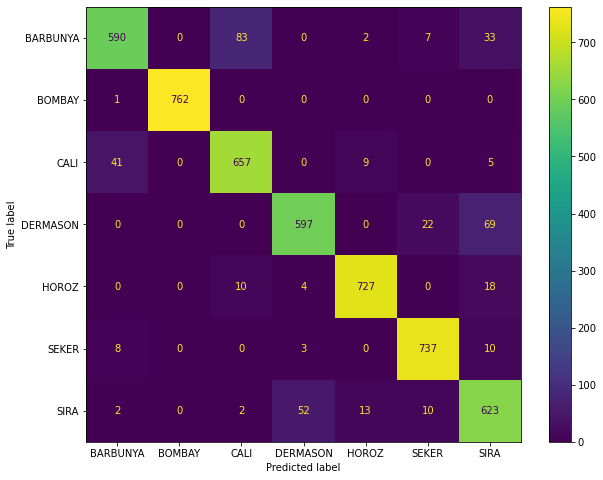

```python
plot_confusion_matrix(logistic, x_val, y_val, display_labels = label_encoder.classes_)
```

```python
y_pred_val = logistic.predict(x_val)
print(classification_report(y_val, y_pred_val))
```

```
              precision    recall  f1-score   support

           0       0.92      0.83      0.87       715
           1       1.00      1.00      1.00       763
           2       0.87      0.92      0.90       712
           3       0.91      0.87      0.89       688
           4       0.97      0.96      0.96       759
           5       0.95      0.97      0.96       758
           6       0.82      0.89      0.85       702

    accuracy                           0.92      5097
   macro avg       0.92      0.92      0.92      5097
weighted avg       0.92      0.92      0.92      5097
```

**🚀 Approach**  
- Both accuracy and Confusion metrix are really good on K-best feature dataset. Let's Try same model with whole dataset

#### Model trained on whole dataset

```python
logistic_whole = LogisticRegression(max_iter=500 )
logistic_whole.fit(x_train_whole, y_train_whole)
```

```
LogisticRegression(max_iter=500)
```

```python
logistic_whole.score(x_train_whole, y_train_whole)
```

```
0.9343255970400269
```

```python
logistic_whole.score(x_val_whole, y_val_whole)
```

```
0.941926623504022
```

```python
logistic_whole.score(x_test_whole, y_test_whole)
```

```
0.914033798677443
```

Wow, This is The accuracy in increased in case of whole dataset, so from this point we are going to use whole dataset

```
<sklearn.metrics._plot.confusion_matrix.ConfusionMatrixDisplay at 0x18557e281f0>
```

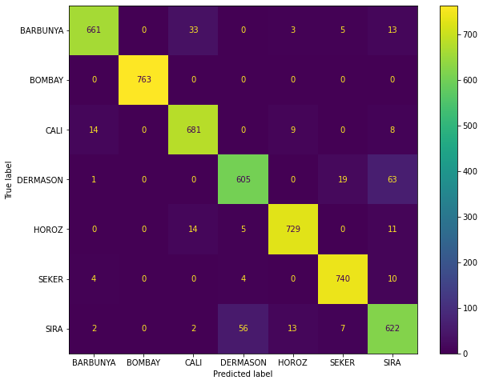

```python
plot_confusion_matrix(logistic_whole, x_val_whole, y_val_whole, display_labels= label_encoder.classes_ )
```

```python
y_pred_val = logistic_whole.predict(x_val_whole)
print(classification_report(y_val_whole, y_pred_val))
```

```
              precision    recall  f1-score   support

           0       0.97      0.92      0.95       715
           1       1.00      1.00      1.00       763
           2       0.93      0.96      0.94       712
           3       0.90      0.88      0.89       688
           4       0.97      0.96      0.96       759
           5       0.96      0.98      0.97       758
           6       0.86      0.89      0.87       702

    accuracy                           0.94      5097
   macro avg       0.94      0.94      0.94      5097
weighted avg       0.94      0.94      0.94      5097
```

```python
cross_val_score(logistic_whole, x_train_whole, y_train_whole, cv = StratifiedShuffleSplit(5))
```

```
array([0.92352941, 0.93445378, 0.93277311, 0.93613445, 0.93277311])
```

**📊 RESULT**  
- Both accuracy and Confusion metrix are really good on whole dataset that k-best feature dataset, So now we are going to use whole dataset.  
- We can select this Logistic model as final one, because it is fast and have really good accuracy, but still let's try XGboost Classifier.

## 3.7 XGBoost Model ⤒

### Model 1

```python
xgboost = XGBClassifier(reg_lambda = 3, n_estimators = 20)
xgboost.fit(x_train_whole, y_train_whole)
```

```
XGBClassifier(base_score=0.5, booster='gbtree', callbacks=None,
              colsample_bylevel=1, colsample_bynode=1, colsample_bytree=1,
              early_stopping_rounds=None, enable_categorical=False,
              eval_metric=None, gamma=0, gpu_id=-1, grow_policy='depthwise',
              importance_type=None, interaction_constraints='',
              learning_rate=0.300000012, max_bin=256, max_cat_to_onehot=4,
              max_delta_step=0, max_depth=6, max_leaves=0, min_child_weight=1,
              missing=nan, monotone_constraints='()', n_estimators=20, n_jobs=0,
              num_parallel_tree=1, objective='multi:softprob', predictor='auto',
              random_state=0, reg_alpha=0, ...)
```

```python
xgboost.score(x_train_whole, y_train_whole)
```

```
0.9763706693575513
```

```python
xgboost.score(x_val_whole, y_val_whole)
```

```
0.9533058661958015
```

```python
xgboost.score(x_test_whole, y_test_whole)
```

```
0.9223610090619643
```

```python
y_pred = xgboost.predict(x_val_whole)
print(classification_report(y_val_whole, y_pred))
```

```
              precision    recall  f1-score   support

           0       0.97      0.96      0.96       715
           1       1.00      1.00      1.00       763
           2       0.96      0.96      0.96       712
           3       0.91      0.91      0.91       688
           4       0.97      0.97      0.97       759
           5       0.97      0.97      0.97       758
           6       0.88      0.89      0.89       702

    accuracy                           0.95      5097
   macro avg       0.95      0.95      0.95      5097
weighted avg       0.95      0.95      0.95      5097
```

```
<sklearn.metrics._plot.confusion_matrix.ConfusionMatrixDisplay at 0x18557e33100>
```

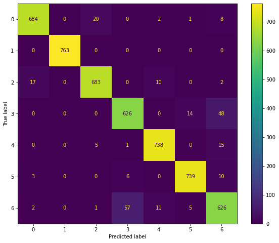

```python
plot_confusion_matrix(xgboost, x_val_whole, y_val_whole)
```

```python
cross_val_score(xgboost, x_train_whole, y_train_whole, cv = StratifiedShuffleSplit(5))
```

```
array([0.95630252, 0.95630252, 0.9487395 , 0.94117647, 0.94369748])
```

### Hyperparameter Tunning

```python
param = {'n_estimators':[50,200], 'max_depth': [10,15], 'reg_lambda':[2]}
xgboost_grid = XGBClassifier()

grid_search_xgb = GridSearchCV(xgboost_grid, param, cv = 2)
```

```python
grid_search_xgb.fit(x_train_whole, y_train_whole)
```

```
GridSearchCV(cv=2,
             estimator=XGBClassifier(base_score=None, booster=None,
                                     callbacks=None, colsample_bylevel=None,
                                     colsample_bynode=None,
                                     colsample_bytree=None,
                                     early_stopping_rounds=None,
                                     enable_categorical=False, eval_metric=None,
                                     gamma=None, gpu_id=None, grow_policy=None,
                                     importance_type=None,
                                     interaction_constraints=None,
                                     learning_rate=None, max_bin=None,
                                     max_cat_to_onehot=None,
                                     max_delta_step=None, max_depth=None,
                                     max_leaves=None, min_child_weight=None,
                                     missing=nan, monotone_constraints=None,
                                     n_estimators=100, n_jobs=None,
                                     num_parallel_tree=None, predictor=None,
                                     random_state=None, reg_alpha=None,
                                     reg_lambda=None, ...),
             param_grid={'max_depth': [10, 15], 'n_estimators': [50, 200],
                         'reg_lambda': [2]})
```

```python
grid_search_xgb.best_estimator_
```

```
XGBClassifier(base_score=0.5, booster='gbtree', callbacks=None,
              colsample_bylevel=1, colsample_bynode=1, colsample_bytree=1,
              early_stopping_rounds=None, enable_categorical=False,
              eval_metric=None, gamma=0, gpu_id=-1, grow_policy='depthwise',
              importance_type=None, interaction_constraints='',
              learning_rate=0.300000012, max_bin=256, max_cat_to_onehot=4,
              max_delta_step=0, max_depth=15, max_leaves=0, min_child_weight=1,
              missing=nan, monotone_constraints='()', n_estimators=200,
              n_jobs=0, num_parallel_tree=1, objective='multi:softprob',
              predictor='auto', random_state=0, reg_alpha=0, ...)
```

```python
grid_search_xgb.best_params_
```

```
{'max_depth': 15, 'n_estimators': 200, 'reg_lambda': 2}
```

```python
grid_search_xgb.best_score_
```

```
0.9455095862764884
```

### Model 2 with hyperparameter result

```python
xgboost_2 = XGBClassifier(reg_lambda = 2, n_estimators = 200, max_depth = 15)
xgboost_2.fit(x_train_whole, y_train_whole)
```

```
XGBClassifier(base_score=0.5, booster='gbtree', callbacks=None,
              colsample_bylevel=1, colsample_bynode=1, colsample_bytree=1,
              early_stopping_rounds=None, enable_categorical=False,
              eval_metric=None, gamma=0, gpu_id=-1, grow_policy='depthwise',
              importance_type=None, interaction_constraints='',
              learning_rate=0.300000012, max_bin=256, max_cat_to_onehot=4,
              max_delta_step=0, max_depth=15, max_leaves=0, min_child_weight=1,
              missing=nan, monotone_constraints='()', n_estimators=200,
              n_jobs=0, num_parallel_tree=1, objective='multi:softprob',
              predictor='auto', random_state=0, reg_alpha=0, ...)
```

```python
xgboost_2.score(x_train_whole, y_train_whole)
```

```
1.0
```

```python
xgboost_2.score(x_val_whole, y_val_whole)
```

```
0.9599764567392584
```

```python
xgboost_2.score(x_test_whole, y_test_whole)
```

```
0.919911829537105
```

```python
y_pred = xgboost_2.predict(x_val_whole)
print(classification_report(y_val_whole, y_pred))
```

```
              precision    recall  f1-score   support

           0       0.97      0.97      0.97       715
           1       1.00      1.00      1.00       763
           2       0.97      0.97      0.97       712
           3       0.91      0.92      0.92       688
           4       0.98      0.97      0.97       759
           5       0.98      0.98      0.98       758
           6       0.90      0.90      0.90       702

    accuracy                           0.96      5097
   macro avg       0.96      0.96      0.96      5097
weighted avg       0.96      0.96      0.96      5097
```

```
<sklearn.metrics._plot.confusion_matrix.ConfusionMatrixDisplay at 0x185570098b0>
```

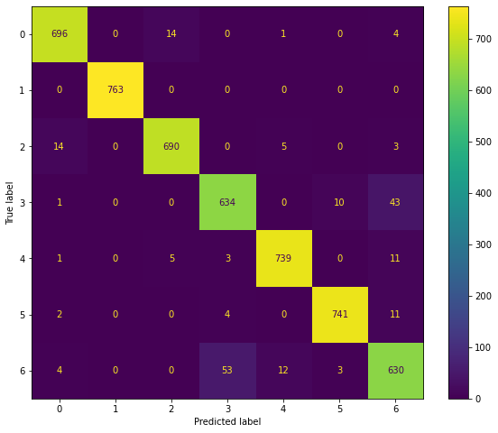

```python
plot_confusion_matrix(xgboost_2, x_val_whole, y_val_whole)
```

```python
cross_val_score(xgboost_2, x_train_whole, y_train_whole, cv = StratifiedShuffleSplit(5))
```

```
array([0.95966387, 0.9487395 , 0.94621849, 0.94285714, 0.94789916])
```

## 3.8 CONCLUSION ⤒

**RESULT**  
- We have tried two models 1. Logistic Regression and 2. XGBoost model. Both models are providing best accuracies and F1 scores but they is a small difference in speed and accuracy  
- Logistic Model accuracy is lower compare to XGBoost, but it is fast and simple  
- XGBoost model accuracy is good as compare to Logistic Model, but it is slower because of Ensembling.  
From These two models I am going to use XGBoost model as final model, because of its performance and there is very small difference between their speeds which i am going to ignore.